# World’s Fairs Visitors

A history of Visitors of the first World’s Fairs

The first World’s Fair took place in 1851 in London. Six million people visited this fair, with the theme being “Industry of All Nations.”

After the first World’s Fair, attendence in the years to come generally increased through the 13th year. After this, the visitor count dropped significantly from 50.8 million in 1900 at fair 13 to 19.69 million in 1904 at fair 14.

However, the 1904 fair was held in the United States. As overseas travel was not as accesible at this time, this would account for the decrease in attendance.

Further, the main exposition at this World’s Fair was the Louisiana Purchase. The lack of attendance could have been because the Louisiana Purchase was mainly a part of the United State’s history and was of little interest to other countries.

This fair started in April of 1939 and did not end until October of 1940. After this long World’s Fair, another large-scale fair was not held until 1958 in Brussels, Belgium, becoming fair 41. Between these two World’s Fairs, there were many smaller “Specialised”Expositions” that focused on different industries, and attendance was not necessarily recorded. This accounts for the plateau in attendance shown in the previous graph.

After the successful fair in New York…

Attendance continued to increase at the World’s Fairs in Brussels, Belgium in 1958…

Montreal, Canada in 1967 for the 45th fair…

and Osaka, Japan in 1970 for the 47th fair.

However, there was one exception: Fair number 43…

Seattle, Washington in 1962.

The sudden plummet in attendance amidst highly-visited fairs is intriguing. According to Historian Grant Wong at the University of South Carolina, “World’s Fairs… have seemingly fallen out of fashion in America.” Wong continues to say that “Outside of the U.S., particularly in Europe and Asia, World’s Fairs remain popular.”

This change in attitude towards the World’s Fairs in the United States explains the drastic difference in the number of visitors at the Seattle fair from the fairs of other countries.

This World’s Fair, held from May of 2010 to Ocotber of 2010, saw the highest number of visitors recorded in the history of World’s Fairs. This could be explained by the large population in China, as well as the ease of travel as compared to earlier occurences of the World’s Fairs.

Using a simple forecasting method that utilizes the mean number of visitors in the past years, it can be predicted that the number of visitors at future fairs will level off and be around 16.6 million.

While we do not know what future World’s Fairs will bring, it will be interesting to see how our ever-changing societal attitudes will impact the turnout of future fairs.

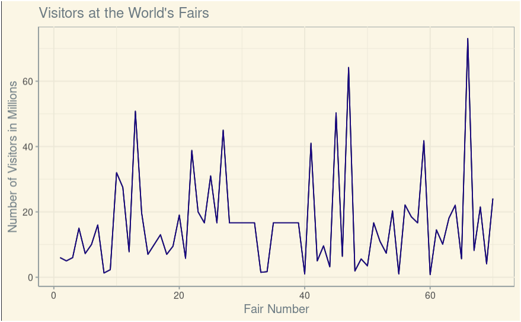

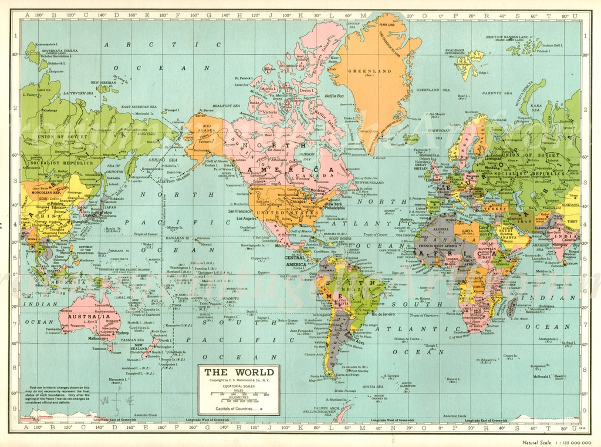

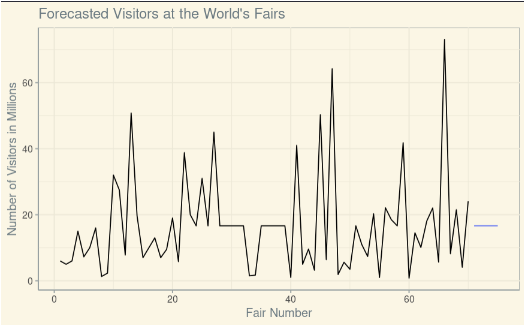

Thanks for reading! If you want to read more about the history of World’s Fairs, check out the rest of the article referenced above!

Source: https://www.smithsonianmag.com/history/the-rise-and-fall-of-worlds-fairs-180979946/

My intended audience is high school students.